# Section 8

###### V. Hunter Adams

```python
from IPython.display import Latex
import matplotlib.pyplot as plt
%matplotlib inline
import numpy
from matplotlib import animation, rc
from IPython.core.display import HTML
from IPython.display import HTML
from ipywidgets import *
from scipy.integrate import odeint
from IPython.display import Image
```

In the previous lecture, Prof. Hayes introduced the *proton-proton chain*, the principle chemical reaction taking place in main sequence stars. In this section, we'll review the proton-proton chain, and talk through the life cycle of a star. Some of this goes beyond the scope of the class, but it's fantastically interesting.

## Protostar

We talked in the past about solar system formation. What starts as a large cloud of gas and dust condenses and spins into a protoplanetary disk, with the protostar at the center. As the collapsing gas condenses, its gravitational potential energy is converted to heat (it has to go somewhere). The rotating sphere of superhot gas (that isn't fusing hydrogen) is called a *protostar*.

## The First Crossroads

#### Less than 0.08 solar masses?

Protostars that don't have enough mass will never reach the temperature required to start nuclear fusion. They will very gradually cool off over hundreds of millions of years, and are known as *brown dwarves* (basically, they're dead before they were ever born).

#### Greater than 0.08 solar masses?

Enter: The Main Sequence.

## Main Sequence Stars

Eventually, the protostar hits a critical temperature (around 10 million Kelvin) that initiates the proton-proton chain. The temperature needs to be this high because the kinetic energy of the protons (which is what temperature is a measure of) must be large enough to overcome the electrostatic repulsion of the protons. They need to be going fast enough to slam into one another, despite the fact that they're both positively charged.

#### Proton-Proton Chain

How do you get Helium from Hydrogen?

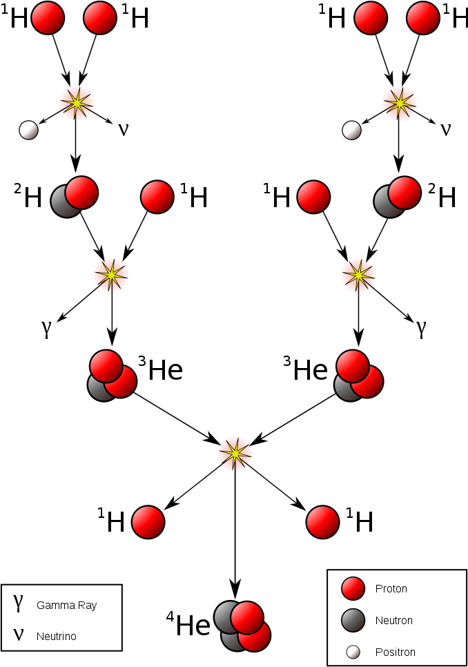

```python
PATH = "/Users/hunteradams/Documents/PhD Semester 5/Sections/"
Image(filename = PATH + "protonproton.png", width=500, height=500)
```

*Question*: How do the two initial protons overcome the Coulomb Barrier?

*Answer*: Quantum Tunneling

*Question*: Which line is a Nobel Prize?

*Answer*: Deuterium

*Question*: Where does energy come from?

*Answer*: The four initial protons weigh more (have more mass) than the final 2 protons and 2 neutrons. Energy comes from the equation

\begin{align} E=mc^2 \end{align}

## Moving Off the Main Sequence

As the star runs out of Hydrogen, the outward pressure from the fusion reactions starts to lose out against the inward pressure from gravity, and the star starts to collapse. As it does so, the internal temperature and pressure within the star begins to rise.

#### Relatively Low-Mass Star?

If the star is of relatively low mass, the temperatures will never get high enough for helium fusion to begin. We have never actually observed what happens to a low mass star after it stops burning hydrogen, because it does so for a period of time longer than the age of the universe. Such stars are fully convective, so they will not develop the degenerate helium cores necessary to turn into a red giant. They will eventually become white dwarves - stars that are not hot enough to undergo fusion, and are maintained only by electron degeneracy pressure. They gradually cool off. When they've completely cooled they become Black Dwarves.

What's degeneracy pressure? Consider the Heisenburg Uncertainty Principle:

\begin{align} \Delta x \Delta p \geq \frac{\hbar}{2} \end{align}

As the matter compresses, the location of the electrons becomes more and more known (since the matter is occupying a smaller and smaller space). As a result, the momentum of these electrons must increase, creating a pressure. When the pressure due to this "Heisenburg motion" exceeds thermal pressure, the electrons are *degenerate*.

#### Slightly More Massive?

Stars that are slightly more massive will have a radiative core, but this core will never get hot enough to start fusing helium. Thus, the star will expand into a red giant as it starts to burn hydrogen in its shell, but it will eventually use up all of its hydrogen and become a white dwarf.

### Mid-Sized Star (Sun)

When a star exhausts the hydrogen in its core, it begins burning hydrogen in a shell around the Helium core. As more hydrogen is burned, the helium core becomes more and more massive. The star expands and cools as the hydrogen burning shell moves farther out from the center. These are Red Giants.

##### Lower Mass?

As more helium is produced, the core becomes supported by *degeneracy pressure*. In this situation, the only thing fighting against the inward pull of gravity is electrons, as described previously. The core continues to increase in temperature, causing the rate of fusion in the hydrogen shell to increase.

If the core is supported by electron degeneracy pressure, then when the temperature reaches a certain limit a *helium flash* occurs. This is an event involving runaway nuclear fusion. When the electron pressure can no longer hold the helium atoms apart, they fuse into heavier elements (Carbon). How does this happen?

In degenerate matter, changes in temperature do not cause a change in volume *until* the thermal pressure becomes so high that it overcomes degeneracy pressure. So, when Helium starts to fuse, the temperature is increased. This increases the fusion rate, which increases the temperature, which increases the fusion rate, etc. It's a runaway reaction that can consume all of the Helium in a star's core in *minutes*, briefly emitting energy at a rate comparable to the entire Milky Way galaxy.

This is almost undetectable, however, because almost all of that energy goes into returning power to thermal pressure from degeneracy pressure, and the little bit of excess is absorbed into the star's upper laters. The core expands and cools, contracting until it is roughly 2 percent of its former radius and luminosity.

Then we have a similar story. We get a degenerate Carbon-Oxygen core and start burning *Helium* in the shell (with Hydrogen burning still occuring in a farther-out shell). As this outer Hydrogen is burned into Helium, the Helium drops into the Helium burning shell, causing periodic *thermal pulses* where energy output from the Helium shell increases dramatically. These are the death-throws of a star.

If the star is not sufficiently massive to start full-scale Carbon burning, they contract again. Much of the outer material becomes a planetary nebula, with the interior becoming a hot central star that cools to a white dwarf.

##### Higher Mass?

In massive stars, the core is large enough for helium burning to begin before the electrons in the core become degenerate. As the core gains material from fusion of Hydrogen at the base of the outer shell, it grows hotter and denser. For these extremely massive stars, electron degeneracy pressure alone is not enough to halt collapse. As a result, progressively heavier elements will ignite within the interior, leading to an onion-like star with the lightest material (Hydrogen) at the outside, and the heaviest material in the core.

If the core is not too massive, it's possible that the star will simply become a white dwarf. Otherwise, we have a far more dramatic story.

Something very important happens when the star has produced elements all the way up to Iron-56 in the core. Up to this point, combining two lighter elements into a heavier element caused a *release* of energy (through $E=mc^2$). However, once we get to Iron-56, this is no longer the case. Creating heavier elements actually *costs* the star energy beyond Iron-56 (the addition of fragments to nuclei releases less energy than required to break them off the parent nuclei). Thus, the star no longer has an energy source for resisting gravity.

If the mass of the core exceeds the *Chandrasekhar Limit*, electron degeneracy will be unable to support the star's weight against its own gravity. Electron capture occurs, which is the process by which electrons combine with protons in the nucleus to produce a neutron, releasing a neutrino. This is sudden and catastrophic.

Energy is transferred from the collapsing core into a shock wave that accelerates rebounding material out into space, and gives it enough energy to crash into each other forming much heavier elements (like Uranium).

What happens next depends on the mass of the star. It may become a *Neutron star*, an extremely dense, extremely quickly rotating object (around 10 km in radius, with a rotational period of over 600 revolutions per second). These rapidlly spinning neutron stars are also called *pulsars*. A teaspoon of neutron star weighs a billion tons.

It's possible, however, that the star is massive enough that neutron degeneracy pressure will not be able to prevent collapse below the Schwarzschild Radius. This stellar remnant becomes a Black Hole.